# Análisis Student Exam Results

Yendali

2025-12-04

# 1 Introducción

El presente análisis explora el dataset *Student Exam Results*, el cual contiene información de **1000 estudiantes** y sus calificaciones en seis materias:

- Hindi
- English
- Science
- Maths
- History
- Geograpgy

Además, incluye tres columnas adicionales:

- **Total**: suma de las seis materias (se elimina por ser redundante)
- **Results**: 0 = reprobado, 1 = aprobado
- **Div**: categorías académicas 0 a 3

El propósito es realizar:

- Exploración descriptiva
- Visualización
- Análisis de correlación
- Análisis de Componentes Principales (PCA)

# 2 Carga de Librerías y Datos

```r
library(tidyverse)
```

```r
library(ggcorrplot)
library(factoextra)
df <- read.csv("Student_Exam_Results.csv")
```

# 3 Limpieza del Dataset

Se elimina la columna Total y se convierten a factor las variables categóricas.

```r
df1 <- df %>%
  select(-Total) %>%
  mutate(
    Results = as.factor(Results),
    Div = as.factor(Div)
  )
summary(df1)
```

```
##      Hindi          English         Science          Maths
##  Min.   : 0.00   Min.   : 0.00   Min.   : 0.00   Min.   : 0.00
##  1st Qu.:26.00   1st Qu.:26.00   1st Qu.:25.00   1st Qu.:25.75
##  Median :53.00   Median :50.50   Median :50.00   Median :49.00
##  Mean   :51.65   Mean   :50.11   Mean   :49.44   Mean   :49.55
##  3rd Qu.:77.00   3rd Qu.:75.00   3rd Qu.:73.25   3rd Qu.:74.00
##  Max.   :99.00   Max.   :99.00   Max.   :99.00   Max.   :99.00
##     History        Geograpgy     Results Div
##  Min.   : 0.00   Min.   : 0.00   0:650   0: 95
##  1st Qu.:24.00   1st Qu.:26.00   1:350   1:206
##  Median :49.00   Median :49.00           2:447
##  Mean   :49.03   Mean   :50.03           3:252
##  3rd Qu.:73.25   3rd Qu.:75.00
##  Max.   :99.00   Max.   :99.00
```

# 4 Distribución de Calificaciones por Materia

A continuación, se visualizan los histogramas de cada materia para observar su dispersión.

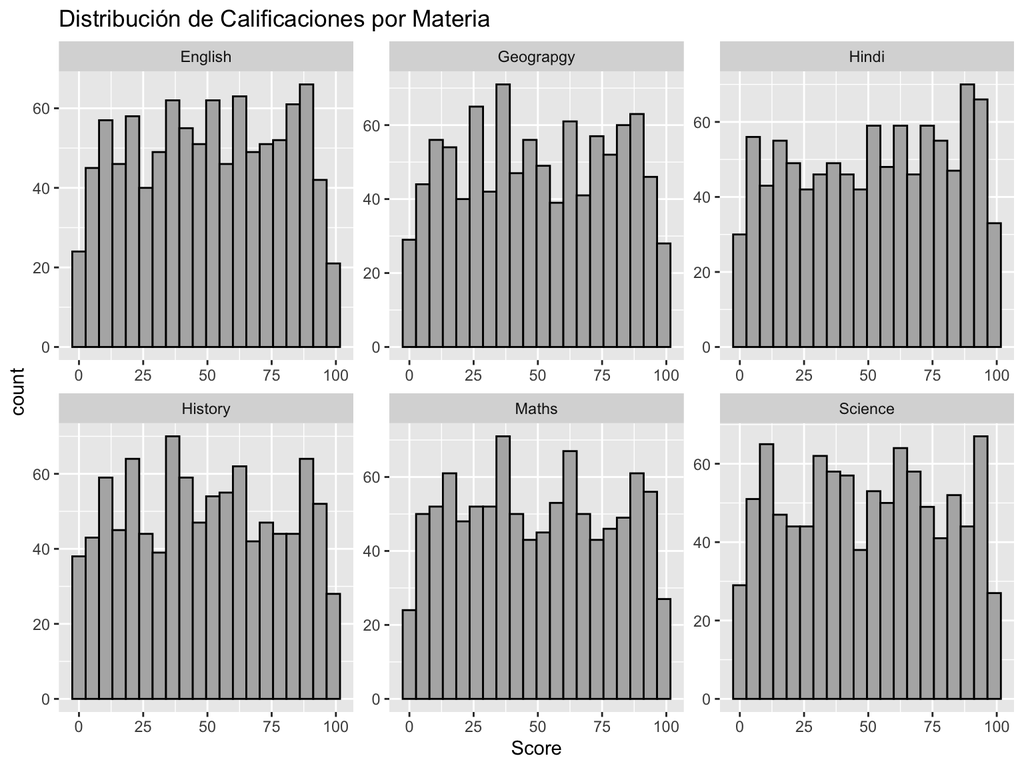

```r
materias <- c("Hindi", "English", "Science", "Maths", "History", "Geograpgy")

df1 %>%
  pivot_longer(cols = materias, names_to = "Materia", values_to = "Score") %>%
  ggplot(aes(x = Score)) +
  geom_histogram(bins = 20, fill="grey70", color="black") +
  facet_wrap(~Materia, scales="free") +
  labs(title = "Distribución de Calificaciones por Materia")
```

# 5 Boxplots por Materia

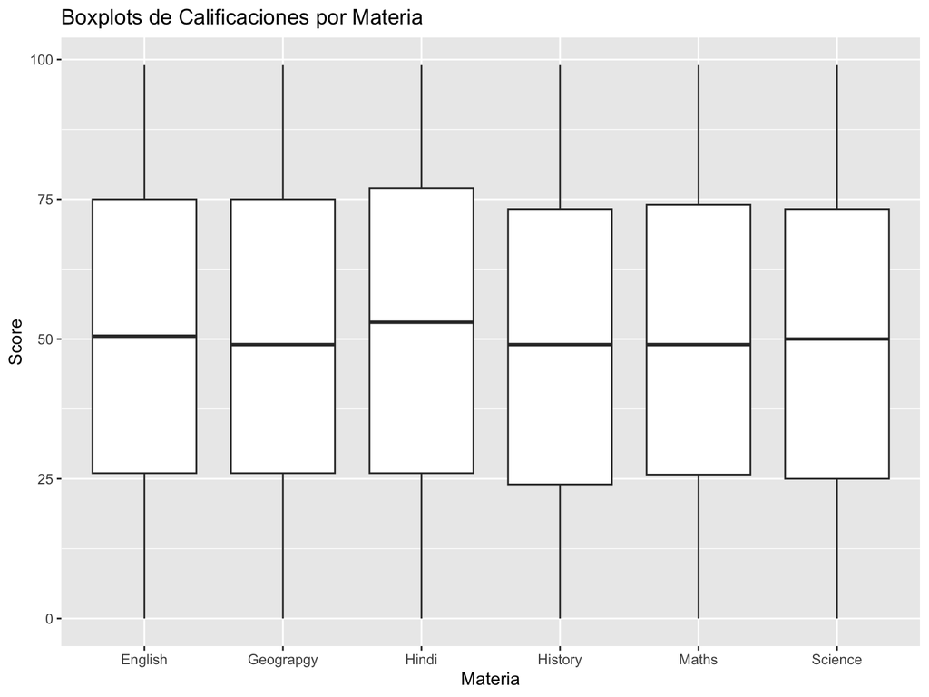

```r
df1 %>%
  pivot_longer(cols = materias, names_to = "Materia", values_to = "Score") %>%
  ggplot(aes(x = Materia, y = Score)) +
  geom_boxplot() +
  labs(title = "Boxplots de Calificaciones por Materia")
```

# 6 Matriz de Correlación

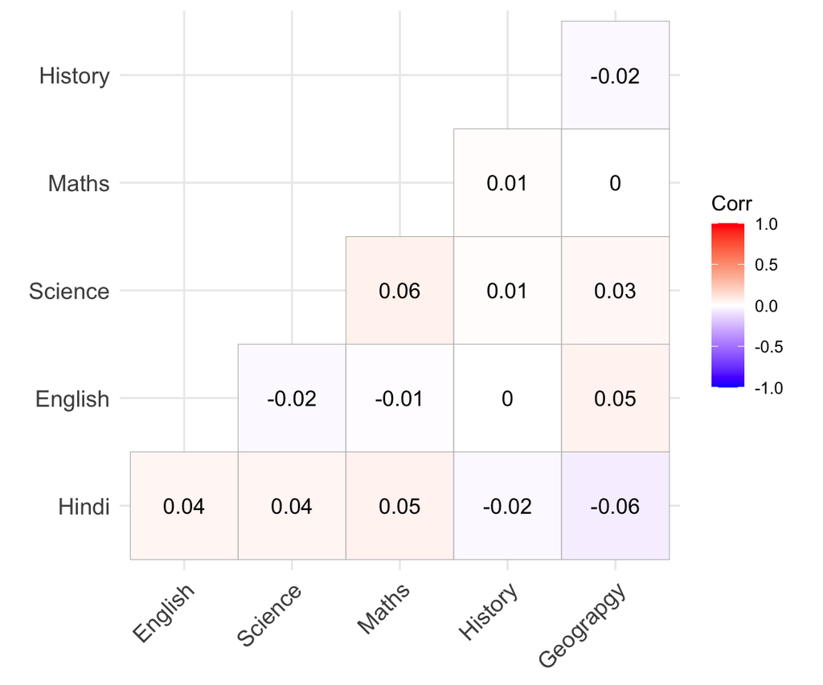

```r
corr_mat <- cor(df1[materias], method = "spearman")
ggcorrplot(corr_mat, type = "lower", lab = TRUE)
```

Las correlaciones entre materias son bajas, lo que indica que el desempeño en una materia no predice fuertemente el desempeño en otra.

# 7 Análisis PCA

Las materias se estandarizan antes de aplicar PCA.

```r
materias_scaled <- scale(df1[materias])
pca_res <- prcomp(materias_scaled, center = TRUE, scale. = TRUE)
summary(pca_res)
```

```
## Importance of components:
##                           PC1    PC2    PC3    PC4    PC5    PC6
## Standard deviation     1.0473 1.0278 1.0182 0.9996 0.9705 0.9322
## Proportion of Variance 0.1828 0.1761 0.1728 0.1665 0.1570 0.1448
## Cumulative Proportion  0.1828 0.3589 0.5316 0.6982 0.8552 1.0000
```

# 8 Scree Plot

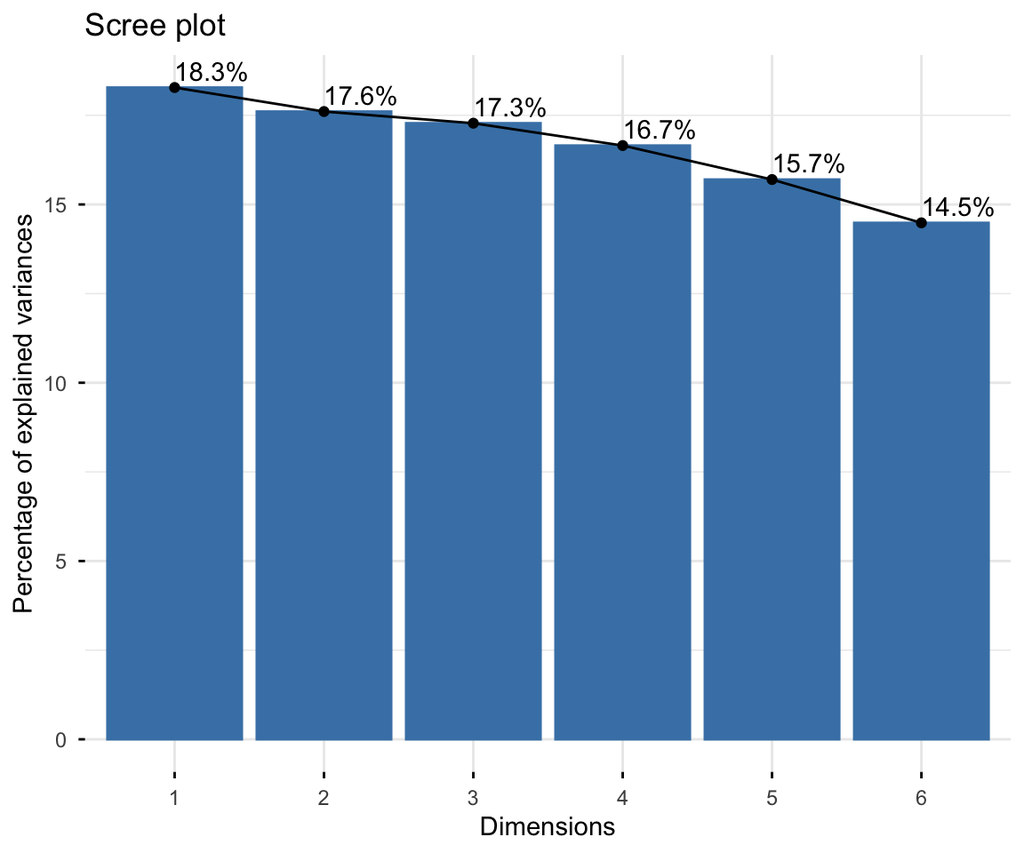

```r
fviz_eig(pca_res, addlabels = TRUE)
```

# 9 Biplot de Variables

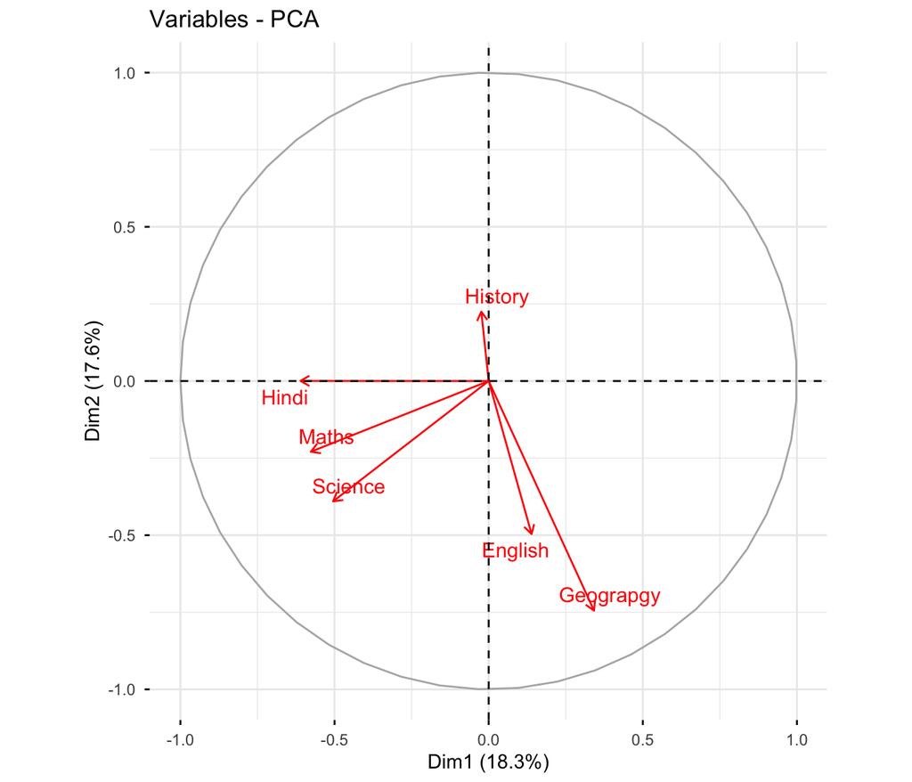

```r
fviz_pca_var(pca_res, repel = TRUE, col.var = "red")
```

# 10 Conclusiones

- Las materias presentan correlación baja, lo que limita la capacidad de PCA para reducir la dimensión del dataset.
- Las dos primeras componentes principales explican alrededor del 35% de la varianza total.
- El PCA funciona como herramienta exploratoria, pero no logra resumir eficientemente la información de las seis materias.